# Morphological (Over-)Generalization

- To what extent is morphology learning driven by vocabulary size vs. age?
- Strawmen theoretical predictions: constructivist that only vocabulary size matters since morphology is generalizing from input, nativist that only age matters since morphology is on a maturational timetable.
- Instead of binary choice between extreme strawmen, doing a data-driven characterization of the relationship between morphology learning, lexical learning, and development – across languages (unfortunately not many though).

# Data

- Four language datasets (American English, Australian English, Danish, Norwegian) CDI WS which have both correct and overregularized forms
- Include verb types for which there’s all three of: stem on vocab checklist (e.g. *go*), correct morphological inflection (e.g. *went*), and overregularized form(s) (e.g. *goed*, *wented*)
- Item coding: https://docs.google.com/spreadsheets/d/1BdpCjlZa3nyF_h091bsjjFgHLkoe-mRf-eGOCZRP75Q
- Exclude kids who don’t produce at least one inflection/overregularization (i.e. dataset of kids who exhibit at least some usage of morphology).
- Following Marchman 1992, for each child on each verb type, code it as:
  - “stem only” if child says stem, doesn’t say inflection nor overregularization(s) e.g. says eat, doesn’t say any of ate/eated/ated
  - “stem + correct” if child says stem and says correct inflection, doesn’t say overregularization(s) e.g. says eat and ate, doesn’t say any of eated/ated
  - “stem + overregularized” if child says stem and says overregularization(s), regardless of whether kid says correct inflection e.g. says eat and any of eated/ated
- There’s a small proportion of cases where parent indicated that child doesn’t say a stem but does say its inflection(s), probably noise.
- For each child, also have age in months and verb vocabulary size (Action Words section of vocbaulary checklist).

Sample sizes:

| language | num_kids | num_stems |
| --- | --- | --- |
| Danish | 6150 | 9 |
| English (American) | 6837 | 16 |
| English (Australian) | 1644 | 16 |
| Norwegian | 20268 | 15 |

Raw data over vocabulary size:

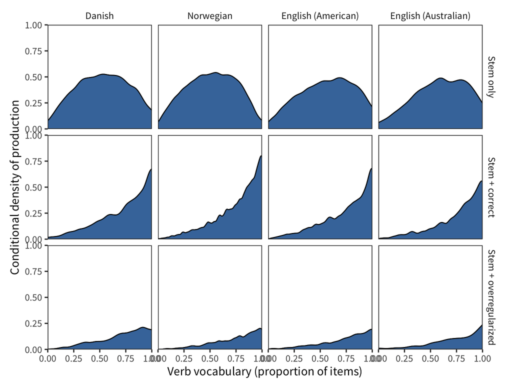

- Stem only goes up and then down, somewhat an artifact of the method because children are running out of the verbs of the form while increasing their knowledge of morphology.
- Correct inflection and overregularization both go up across vocab range, look non-linear.
- Overregularization considerably lower than correct inflection.

# Model selection

- For each measure (stem only, stem + correct, stem + overregularized), predict true/false values from some combination of age, linear verb vocabulary size, quadratic verb vocabulary size, and interactions between age and verb vocabulary size.
- All with random intercepts for stem.
- For each model, cross-validate it by splitting data (by children) into 10 subsamples; for each subsample, train model on remaining 90% of data and predicting the value in the 10% subsample.
- Evaluate prediction by computing mean squared prediction error (MSE), take mean MSE across subsamples.
- Plot below shows 1 - mean MSE so that bigger is better, best model circles.

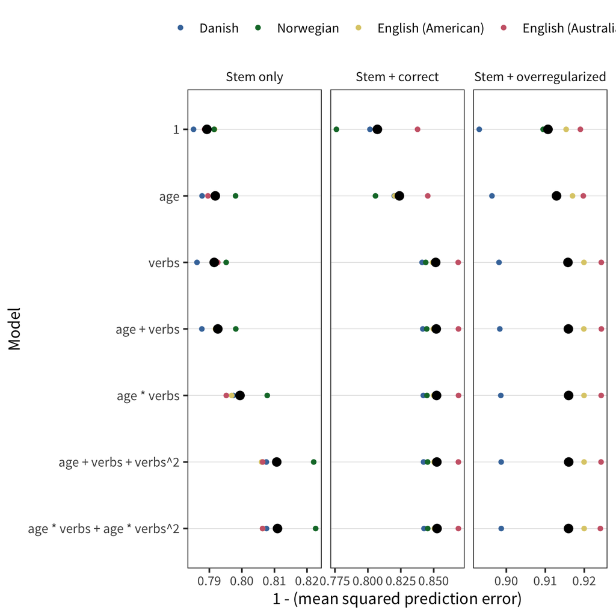

- Most complex model (both quadratic vocab term and interactions) wins for all measures for all languages except Australian English.
- Probably because Australian English is a much smaller sample than the others so it’s overfitting.

# Model results

- For best models as selected above, fit to the whole dataset.
- Look at various model predictions to understand effects (averaged over stems).

## Stem only

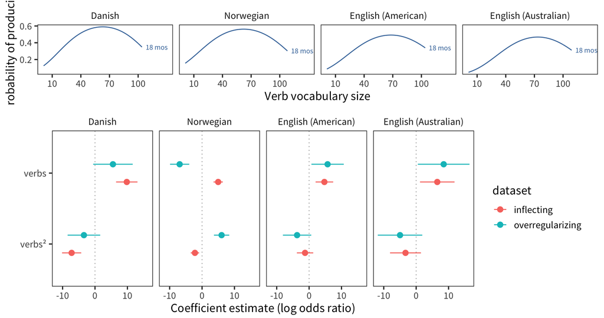

- Positive linear effects of verb vocbaulary: more verbs means more likely to produce stem only.
- Negative quadratic effect of verb vocabulary: more verbs first increases probability of producing stem only, but then decreases it.

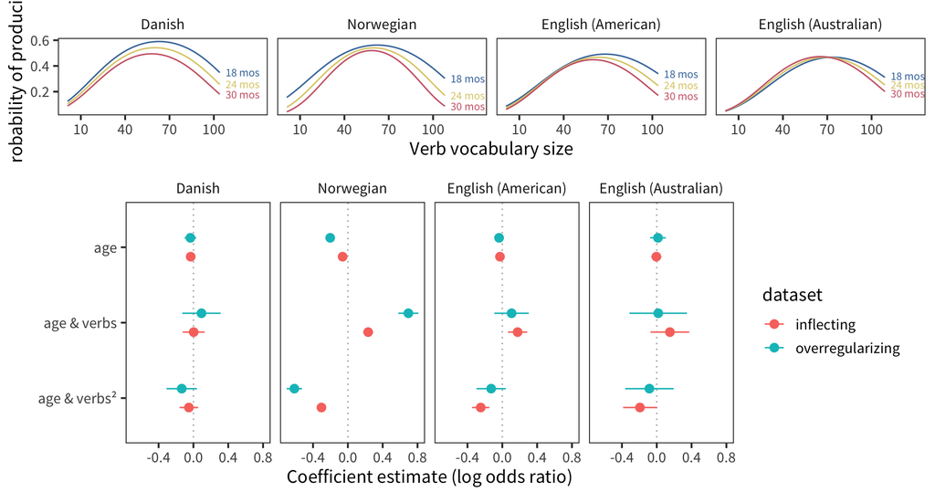

## Stem + correct

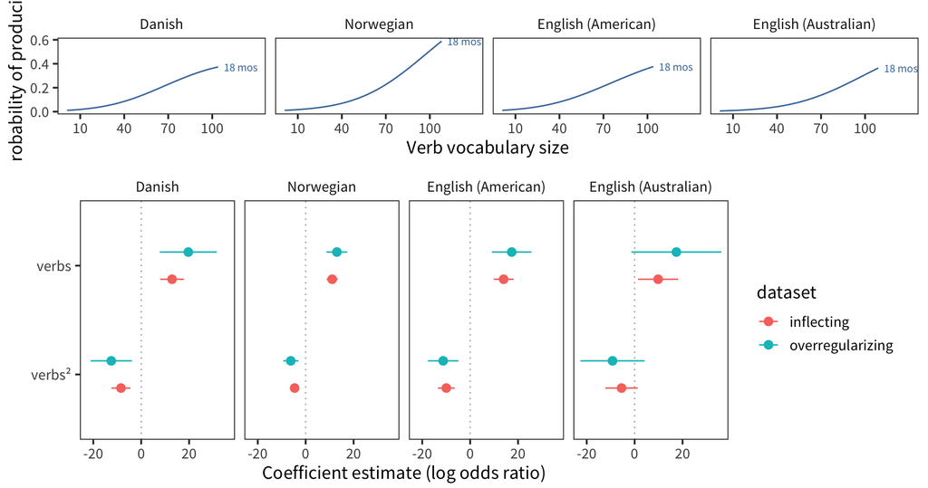

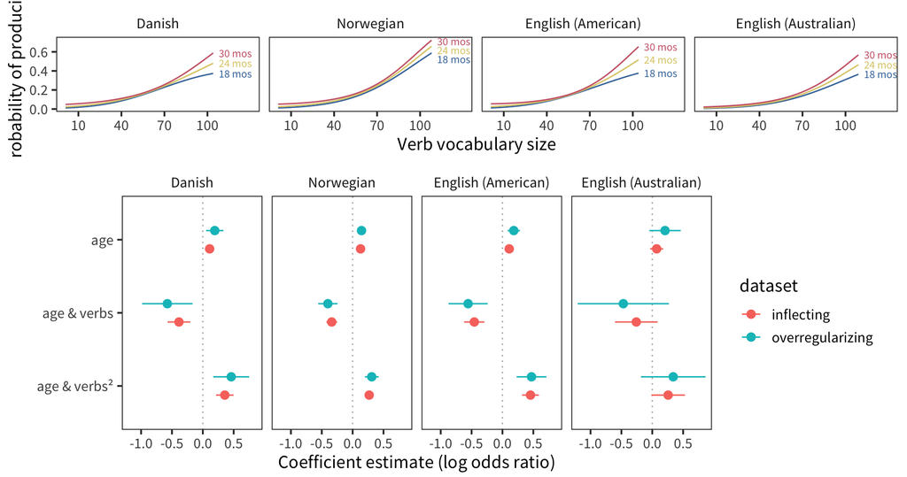

- Positive effects of age: older children more likely produce stem + correct.
- Negative interactions between age and linear verb vocabulary: larger effect of verb vocabulary for younger children.
- Positive interactions between age and quadratic verb vocabulary: curvier effect of verb vocabulary for older children.

## Stem + overregularized

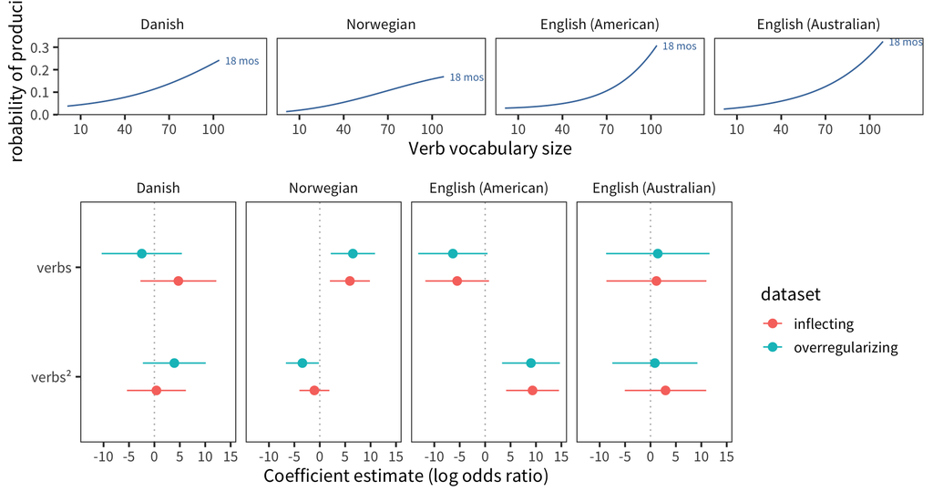

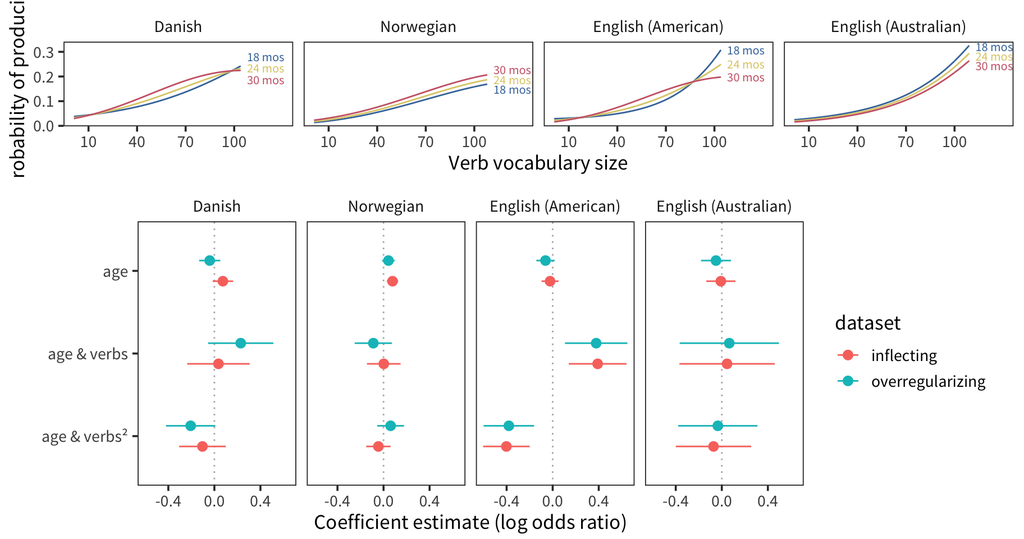

- Positive effects of age: older children more likely produce stem + overregularized.
  - American English has weird noisy stuff happening at the end of the range.
- Positive interactions between age and linear verb vocabulary: larger effect of verb vocabulary for older children.
- Negative interactions between age and quadratic verb vocabulary: curvier effect of verb vocabulary for younger children.